# LEGO Sets

yq

2023-11-29

#### Importing libraries and data

```r
#importing data and libraries
library(tidyverse)
library(tidytuesdayR)
library(ggrepel)
library(ggthemes)
library(viridis)

url='https://raw.githubusercontent.com/rfordatascience/tidytuesday/master/data/2022/2022-09-06/'

sets <- readr::read_csv(paste0(url, 'sets.csv.gz'))
themes <- readr::read_csv(paste0(url, 'themes.csv.gz'))
```

## Introduction

The LEGO data set consists of data from the Rebrickable database. Every official LEGO’s parts, sets, colours and inventory data can be obtained from the following data set. In this case study, we will be delving into the question: **What should manufacturers take into consideration when making a new LEGO set?** We find this to be an important question as manufacturers have the main goal of maximising profits from an introduction of a new LEGO set, hence would benefit from releasing a LEGO set that has the highest potential of becoming popular. This question would help manufacturers to narrow down on what themes to focus their efforts on, and we will evaluate the sets based on its sustainability and popularity in the long run and the size of a set in terms of the number of parts it has. We will be focusing on the sets and themes datasets to answer the question. In the sets dataset, the variables `year`, `num_parts`, `theme_id` and `set_num` will be of interest. The `year` consists of the year that a LEGO set was released, `num_parts` indicates the number of parts in a set ,`theme_id` is the theme of a set, while `set_num` is an ID for each unique set. In the themes dataset, the variables `id` and `parent_id` will be of interest. The `id` is the unique ID for each theme, inclusive of both main and sub themes. Whereas the `parent_id` is the overarching theme of a sub theme, only present if the theme is a sub theme. It is expected that the popularity of a LEGO set can be influenced by multiple factors. In this case, we will make the assumption that manufacturers continue to sell sets as they believe there is sustained interest or potential for growth in that theme.

## Data cleaning & Summary

```r
sets %>% filter(num_parts == 0) %>% count()
```

```
## # A tibble: 1 × 1
##       n
##   <int>
## 1  3630
```

There exist 3630 rows of sets with 0 number of parts. As we are unsure if it was due to an error when the data was collected or other reasons, we decided to remove them from the data set to ensure that our analysis is focused on instances when the Lego set actually contains parts, as sets with no parts provide no meaning to the question that we are investigating.

```r
sets = sets %>% filter(num_parts != 0)

n_themes = themes %>% count()
themes %>% head(3)
```

```
## # A tibble: 3 × 3
##      id name           parent_id
##   <dbl> <chr>              <dbl>
## 1     1 Technic               NA
## 2     3 Competition            1
## 3     4 Expert Builder         1
```

There are 445 total themes during the initial observation, however upon closer inspection, we identified that there are sub-themes within themes. For example, the themes *Airport*, *Cargo* and *Construction* have the same `parent_id` of 52 which is the `id` of the theme *City*. Therefore we decided to classify them under the base theme of *City* to reduce the number of total themes. This is also done as sub-themes are closely related to each other and their parent themes, combining them under the same base theme helps to reduce redundancy in the analysis later on.

```r
theme_base = themes %>%
  left_join(themes, by=c("parent_id" = "id"), suffix = c("", "_parent"))

theme_base %>% filter(!is.na(parent_id_parent)) %>% count() %>% pull()
```

```
## [1] 22
```

After self-joining, there is still another layer of parent themes, so we self-join again.

```r
theme_base = theme_base %>%
  left_join(theme_base, by=c("parent_id_parent" = "id"),
            suffix = c("", "_parent")) %>%
  select(-8, -9)

theme_base %>% filter(!is.na(parent_id_parent_parent)) %>%
  count() %>% pull()
```

```
## [1] 0
```

Since there are no more parent themes, there are only 3 layers of themes, and we do not have to self join again. We then clean the `theme_base` table, showing only the base theme for each `theme_id`

```r
theme_base = theme_base %>%
  select(-5, -7, name_root = name_parent_parent) %>%
  mutate(name_parent = ifelse(is.na(name_parent), name, name_parent)) %>%
  mutate(name_root = ifelse(is.na(name_root), name_parent, name_root)) %>%
  select(id, theme_name = name_root)

n_basethemes = theme_base %>% select(theme_name) %>%
  unique() %>% count() %>% pull()
```

We have narrowed down 445 themes to 141 base themes. This will help to provide a more concise representation of the main themes, allowing us to extract key insights at a higher level which is valuable as we are analysing the overarching trends, for manufacturers and stakeholders.

We then join the `sets` table with the `theme_base` table, naming it `sets_with_themes` so the `theme` column is in the table.

```r
sets_with_themes <- sets %>%
  left_join(theme_base, by = c("theme_id" = "id"))
```

We observed that there is a theme named *Other*, which is usually used to classify miscellaneous items that do not fit into any of the predefined main themes. This category lacks specific information and provides little to no insight to the data, hence we decided to remove it to improve clarity as we are focusing on meaningful information that manufacturers can act upon. We also remove the `img_url` column as we do not use it for our analysis.

```r
theme_base = theme_base %>%
  filter(theme_name != "Other")
sets_with_themes = sets_with_themes %>%
  filter(theme_name != "Other") %>%
  select(!img_url)

n_sets = sets_with_themes %>% count() %>% pull()
sets_with_themes %>% summarize(max_parts = max(num_parts), min_parts = min(num_parts))
```

```
## # A tibble: 1 × 2
##   max_parts min_parts
##       <dbl>     <dbl>
## 1     11695         1
```

### Visualisation 1: Compare Number Of Years In Production of the Top 15 Most Popular Themes and looking at their Number of Lego Sets Produced

[figure not shown]

```r
sets_with_themes %>%
  group_by(theme_name) %>%
  mutate(diff = max(year)- min(year), count=n()) %>%
  select(theme_name,diff,count) %>%
  distinct()%>%
  arrange(desc(count))%>%
  head(15)%>%
  select(theme_name,diff,count)-> popularity

ggplot(data = popularity, aes(x = count, y = diff)) +
  geom_point()+
  geom_smooth(method = "loess", se=F, span=0.7, col = viridis(1)) +
  geom_text_repel(aes(label= str_to_title(theme_name)))+
  theme_minimal() +
    labs(title="Number of Lego Sets and Years In Production for the Top 50 themes",
       x = "Number of Lego Sets Produced", y = "Years In Production") +
  theme(panel.grid.minor = element_blank(),panel.grid.major.x =
          element_blank(),plot.title = element_text(hjust = 0.5, face = "bold"),
        axis.title.y = element_text(margin=margin(r=15)),
        axis.title.x = element_text(margin=margin(t=10))) -> Figure_1

Figure_1
```

For this visualisation, we will be visualising the relationship of number of Lego sets and years in production of the Top 15 most popular themes. We will be assuming that themes with a higher number of Lego sets are more popular. We will be using `sets_with_themes` dataset, which was composed of the self joining of `themes` and a left join onto `sets` dataset as shown in the data cleaning above. Here, 2 new variables are created. The data is grouped by `theme_names` and the variable `diff` calculates the difference between the maximum and minimum years within each group, yielding the number of years each main theme has been in production. While the `count` variable represents the number of lego sets under each main theme.

For visualisation purposes, only the top 15 most popular themes, based on their number of Lego sets, are included in the plot. A scatterplot is well suited here as it provides a clear visualisation of the relationship between the 2 continuous variables and also underlying patterns. A regression line fitted using the Loess method is also plotted as it helps highlight the overall and underlying trend. In addition, the text labels enable us to discern which particular themes are more sustainable, in terms of longer years in production, and popular, in terms of their number of Lego sets, which grants us more information.

In Figure 1, we are able to discern a general upward trend between the years in production of the top 15 themes and their number of lego sets. This helps us to understand that themes with higher popularity, in terms of their number of Lego sets, are more likely to be sustainable as well. This association is a good consideration for manufacturers to take into account. In particular, we can also identify that *Educational and Dacta* and *Duplo* themes stand out significantly in terms of their sustainability and popularity. These themes are possible reliable choices for the production of new lego sets that manufacturers can consider. In addition, we can observe that the trend line takes a dip in the middle of the graph, this is likely due to themes such as *City*, *Star Wars* and *Collectible Minifigures* that have a high number of Lego sets despite only being in production for a short term. Thus, these themes are possible emerging choices in terms of popularity as compared to the other themes that can be taken into consideration by the manufacturer as well in making new lego sets.

### Visualisation 2: Observing how complexity of theme affects popularity in the top themes in recent years

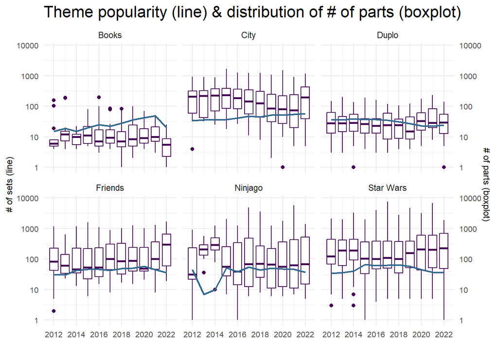

```r
#Collectible Minifigures are removed as they are
#a special type of theme with an extremely low # of parts,
#which is not useful in our specific analysis for this visualization
top_theme_1222 = sets_with_themes %>%
  filter(between(year, 2012, 2022), theme_name != "Collectible Minifigures") %>%
  count(theme_name, sort=TRUE) %>%
  head(6) %>% pull(theme_name)

theme_count = sets_with_themes %>%
  filter(theme_name %in% top_theme_1222, between(year, 2012, 2022)) %>%
  group_by(year) %>%
  count(theme_name)

sets_with_themes %>%
  filter(theme_name %in% top_theme_1222, between(year, 2012, 2022)) %>%
  ggplot() +
  geom_boxplot(aes(year, num_parts, group = year), col = viridis(1)) +
  geom_line(data = theme_count, aes(year, n), col=viridis(4)[2], lwd = 0.75) +
  scale_y_log10(sec.axis = sec_axis(trans=~.*1,
                                    name = "# of parts (boxplot)")) +
  scale_x_continuous(breaks = seq(2012, 2022, 2)) +
  facet_wrap(~theme_name) +
  labs(title = "Theme popularity (line) & distribution of # of parts (boxplot)",
       x="", y="# of sets (line)") +
  theme_minimal() +
  theme(plot.title = element_text(size = 16),
        axis.text = element_text(size = 8),
        axis.title = element_text(size = 9)) -> Figure_2

Figure_2
```

This visualisation offers a comprehensive exploration of the relationship between the popularity and complexity of LEGO themes from 2012 to 2022, focusing on the top 6 themes (based on number of sets released during 2012-2022). The line graph charts the annual evolution of each theme by depicting the number of sets released over the 10-year period, which serves as a proxy for theme popularity, as an increasing number of sets released might signify sustained interest and demand. The boxplots display the distribution of the number of LEGO parts in the sets each year, which provide a nuanced perspective on the complexity of sets within each theme.

This overlay of line graphs and boxplots serves as a powerful analytical tool, allowing us to discern patterns and correlations that might be overlooked when examining each aspect independently. By simultaneously considering popularity and complexity, the visualisation provides a holistic understanding of the top LEGO themes, empowering manufacturers with valuable insights into the factors influencing a set’s success. Manufacturers should carefully weigh the trade-off between releasing a diverse array of themes and maintaining the complexity of individual sets, as this delicate balance can greatly impact the market reception of LEGO products.

### Visualisation 3: Popularity of movie/tv series and the influence of the number of its lego themes across 1999 to 2022.

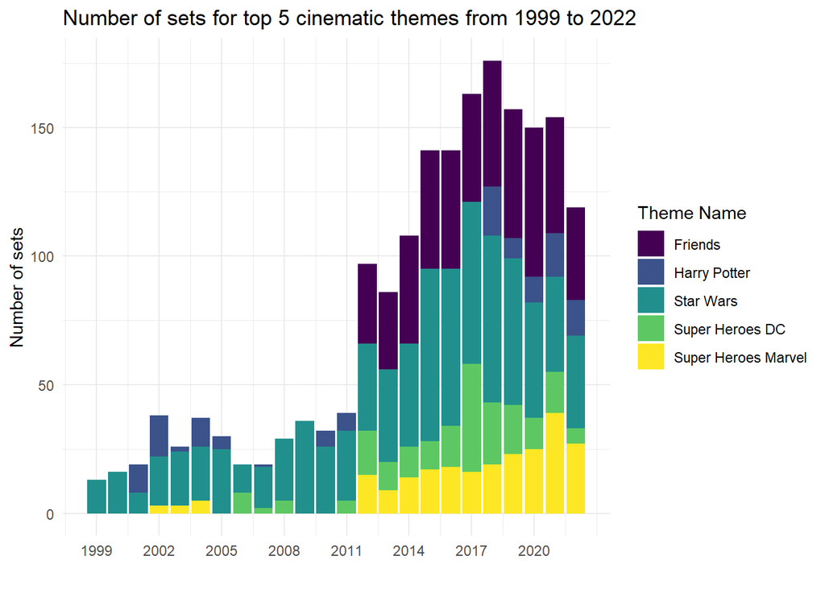

```r
top_themes = sets_with_themes %>% count(theme_name, sort = TRUE) %>% head(35)

#manually extracting themes that are TV Shows/Movies
shows = c("Star Wars", "Friends", "Super Heroes Marvel", "Super Heroes DC", "Harry Potter")

sets_with_themes %>% filter(theme_name %in% shows) %>%
  group_by(year) %>%
  count(theme_name) %>%
  ggplot(aes(x = year, y = n, fill = theme_name)) +
  geom_col() +
  scale_x_continuous(breaks = seq(1999,2022,3)) +
  labs(title = "Number of sets for top 5 cinematic themes from 1999 to 2022",
       x = "", y = "Number of sets", fill = "Theme Name") +
  scale_fill_viridis_d() +
  theme_minimal() -> Figure_3

Figure_3
```

The stacked bar plot shows the change in number of sets of top 5 cinematic lego themes across the years 1999 to 2022 (The first set with a cinematic theme was introduced in 1999). Each bar shows the proportion of cinematic themes for that year, with the themes grouped by colour.

A stacked bar plot is a suitable visualisation as it shows the change in the total number of lego sets for the top 5 themes. For each year as signified by a bar, we can clearly see the proportion of each theme in a single year. This allows us to see what themes dominated the lego sets, and allows us to check if this corresponds to events such as the release of a movie/show for that theme, thus incentivising manufacturers to produce more lego sets in a theme.

For example, Harry Potter, an incredibly popular book series, aired its first film in 2001. This corresponds with an increase in the number of Harry Potter themed lego sets as manufacturers viewed the popularity of the film as an opportune moment to sell similarly themed LEGO sets to its fans, which was released in 2001. Similarly, Friends, a hugely popular TV series, was aired from 1994 to 2004. However, the first Friends themed lego sets were only released in January 2012, but remained a very popular lego theme till 2022. We can infer that despite releasing its related LEGO sets much later after the show had already run, it was still feasible and profitable for manufacturers to produce sets on the films as the public may still enjoy references on the film and were keen on purchasing collectibles such as its LEGO sets. In addition, DC movies became popular after 2012, having the largest number of sets in 2017 possibly due to the release of two DC movies as compared to one movie in other years.

## Discussions

In conclusion, the visualisations collectively offer manufacturers a comprehensive perspective on theme selection, longevity, and strategic alignment with media events. They underscore the need to balance popularity and complexity in new set introductions, empowering manufacturers to navigate the intricate landscape of LEGO set production with strategic foresight. These insights facilitate informed decision-making, ensuring that manufacturers capitalise on sustained themes, identify growth opportunities, and strategically align with media trends for maximum market impact.

## References:

Lego sets. GitHub. (2022, September 6). https://github.com/rfordatascience/tidytuesday/tree/master/data/2022/2022-09-06  
DCEU movies in order – DCEU timeline and chronological order - odeon. (n.d.). https://www.odeon.co.uk/odeon-scene/dceu-movies-in-order/